# BIOL606_hw_Lecture18_Hastings

2025-04-23

# Homework Lecture 18

Run a NMDS on the bird data (macnally_full2.csv, leave out columns 1&2, SITE + HABITAT), using Bray-Curtis as the distance metric with the vegan metaMDS function.

```r
# Load dataset.
mac <- read_csv("macnally_full2.csv") # Load in data set.
# Factorize SITE and HABITAT variables.
mac[, c(1, 2)] <- lapply(mac[, c(1, 2)], as.factor)

# Check the structure of the data.
glimpse(mac)
```

```
## Rows: 37
## Columns: 104
## $ SITE    <fct> Reedy Lake, Pearcedale, Warneet, Cranbourne, Lysterfield, Red …
## $ HABITAT <fct> Mixed, Gipps.Manna, Gipps.Manna, Gipps.Manna, Mixed, Mixed, Mi…
## $ GST     <dbl> 3.4, 3.4, 8.4, 3.0, 5.6, 8.1, 8.3, 4.6, 3.2, 4.6, 3.7, 3.8, 5.…
## $ EYR     <dbl> 0.0, 9.2, 3.8, 5.0, 5.6, 4.1, 7.1, 5.3, 5.2, 1.2, 2.5, 6.5, 6.…
## $ GF      <dbl> 0.0, 0.0, 0.7, 0.0, 12.9, 10.9, 6.9, 11.1, 8.3, 4.6, 6.3, 11.1…
## $ BTH     <dbl> 0.0, 0.0, 2.8, 5.0, 12.2, 24.5, 29.1, 28.2, 18.2, 6.5, 24.9, 3…
## $ GWH     <dbl> 0.0, 0.0, 0.0, 2.0, 9.5, 5.6, 4.2, 3.9, 3.8, 2.3, 2.8, 6.2, 3.…
## $ WTTR    <dbl> 0.0, 0.0, 0.0, 0.0, 2.1, 6.7, 2.0, 6.5, 4.2, 5.2, 7.4, 8.5, 8.…
## $ WEHE    <dbl> 0.0, 0.0, 10.7, 3.0, 7.9, 9.4, 7.1, 2.6, 2.8, 0.6, 1.3, 2.3, 2…
## $ WNHE    <dbl> 11.9, 11.5, 12.3, 10.0, 28.6, 6.7, 27.4, 10.9, 9.0, 3.6, 4.7, …
## $ SFW     <dbl> 0.4, 8.3, 4.9, 6.9, 9.2, 0.0, 13.1, 3.1, 3.8, 3.8, 5.5, 8.2, 4…
## $ WBSW    <dbl> 0.0, 12.6, 10.7, 12.0, 5.0, 8.9, 2.8, 8.6, 5.6, 3.0, 9.5, 5.9,…
## $ CR      <dbl> 1.1, 0.0, 0.0, 0.0, 19.1, 12.1, 0.0, 9.3, 14.1, 7.5, 5.7, 10.5…
```

[output cut: 91 more lines]

```r
# Peek at 5 random rows.
mac |>
  slice_sample(n = 5)
```

```
## # A tibble: 5 × 104
##   SITE       HABITAT   GST   EYR    GF   BTH   GWH  WTTR  WEHE  WNHE   SFW  WBSW
##   <fct>      <fct>   <dbl> <dbl> <dbl> <dbl> <dbl> <dbl> <dbl> <dbl> <dbl> <dbl>
## 1 Lysterfie… Mixed     5.6   5.6  12.9  12.2   9.5   2.1   7.9  28.6   9.2   5
## 2 Bittern    Gipps.…   6.5   9.7   7.8  14.4   5.2   0    11.5  12.5  20.7   4.9
## 3 Hawke      Mixed     1.7   2.6   5.5  16     4.3   6.7   3.5   5.9   6.7  10
## 4 Panton Gap Montan…   3.8   3.8  10.3  34.6   7.9   4.8   2.9   3.7   4.8   7.2
## 5 Heathcote… Montan…   3.7   2.5   6.3  24.9   2.8   7.4   1.3   4.7   5.5   9.5
## # ℹ 92 more variables: CR <dbl>, LK <dbl>, RWB <dbl>, AUR <dbl>, STTH <dbl>,
## #   LR <dbl>, WPHE <dbl>, YTH <dbl>, ER <dbl>, PCU <dbl>, ESP <dbl>, SCR <dbl>,
## #   RBFT <dbl>, BFCS <dbl>, WAG <dbl>, WWCH <dbl>, NHHE <dbl>, VS <dbl>,
## #   CST <dbl>, BTR <dbl>, AMAG <dbl>, SCC <dbl>, RWH <dbl>, WSW <dbl>,
## #   STP <dbl>, YFHE <dbl>, WHIP <dbl>, GAL <dbl>, FHE <dbl>, BRTH <dbl>,
## #   SPP <dbl>, SIL <dbl>, GCU <dbl>, MUSK <dbl>, MGLK <dbl>, BHHE <dbl>,
## #   RFC <dbl>, YTBC <dbl>, LYRE <dbl>, CHE <dbl>, OWH <dbl>, TRM <dbl>, …
```

```r
# Isolate habitat grouping variable for visualizations.
habitat <- mac[, 2]  # Column 2 is habitat type

# Remove SITE
bird_data <- mac[, -c(1,2)]
```

**Tasks:**

Generate a NMDS ordination plot showing the sites only (no species arrows), and draw ellipsoid hulls around each of the 6 habitat types to show how habitat maps onto the ordination.

Color the site points by HABITAT type (column 2 of data frame)

Use the ordiellipse() function to draw an ellipse enclosing each Habitat group. The groups argument should be defined using the HABITAT data in column 2 of the data frame.

Include a legend in the plot to show which point color maps to which habitat type.

```r
# Perform NMDS using Bray-Curtis distance.
set.seed(420)  # For reproducibility.
mac_nmds <- metaMDS(bird_data, distance = "bray", k = 2, trymax = 100)
```

```
## Square root transformation
## Wisconsin double standardization
## *** Best solution repeated 7 times
```

```r
# Check stress.
mac_nmds$stress
```

```
## [1] 0.1175806
```

```r
# Assign colors to each habitat type.
habitat_colors <- c(
  'Gippsland manna gum' = 'red',
  'montane forest' = 'blue',
  'woodland' = 'green',
  'box-ironbark' = 'purple',
  'river redgum' = 'orange',
  'mixed forest' = 'brown'
)

# Confirm that mac_nmds site scores align with mac_data rows.
identical(rownames(bird_data), rownames(mac_nmds$points))  # Should be TRUE.
```

```
## [1] TRUE
```

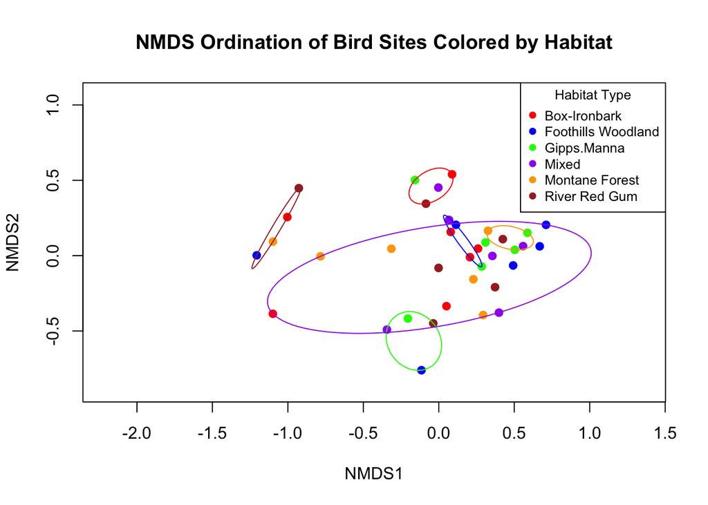

```r
# Generate NMDS ordination plot - sites only.
plot(mac_nmds, type = 'n')
points(mac_nmds, display = 'sites', pch = 19, col = habitat_colors)  # Colored points by habitat.
title('NMDS Ordination of Bird Sites Colored by Habitat')

# Draw ellipses around each habitat group in the NMDS ordination plot.
ordiellipse(mac_nmds,
  groups = mac$HABITAT,
  kind = 'ehull', # Ellipses are based on covariance since groups are small with outliers.
  conf = 0.95, # Confidence level.
  col = habitat_colors,
)

# Add a legend to the NMDS plot to indicate which colors correspond to each habitat type.
legend(
  'topright',
  legend = levels(mac$HABITAT),
  col = habitat_colors,
  pch = 19, # Use solid circle symbols.
  title = 'Habitat Type',
  cex = 0.8 # Size scaling for the legend text.
)
```

*Based on your plot, describe which (if any) of the habitats differ in community composition.*